# Assignment 2 - Spatial Representation Comparison

In this assignmnet we will be experimenting with spacial representations of data. The shapes we will be working with are :

- Triangle
- Circle

Each of the shape wiil be used to visualize data different in magnitude in the following way -

*The numbers are identical.*

*The numbers have a difference of a factor of dozen.*

*The numbers have a difference of a factor of hundred.*

For each of the shape, I have identified **4** visual styles. viz. `Filled`, `Blurred`, `Nofill` and `Dashed`. Each of these styles will be experimented by placing the objects *side-by-side* or *inside* each other. Furthermore, the effect of their position, scaling and orientation will also be looked upon. We will first begin with Triangles.

# 1. Triangles with identical area

In this step the areas of the triangle are nearly identical.

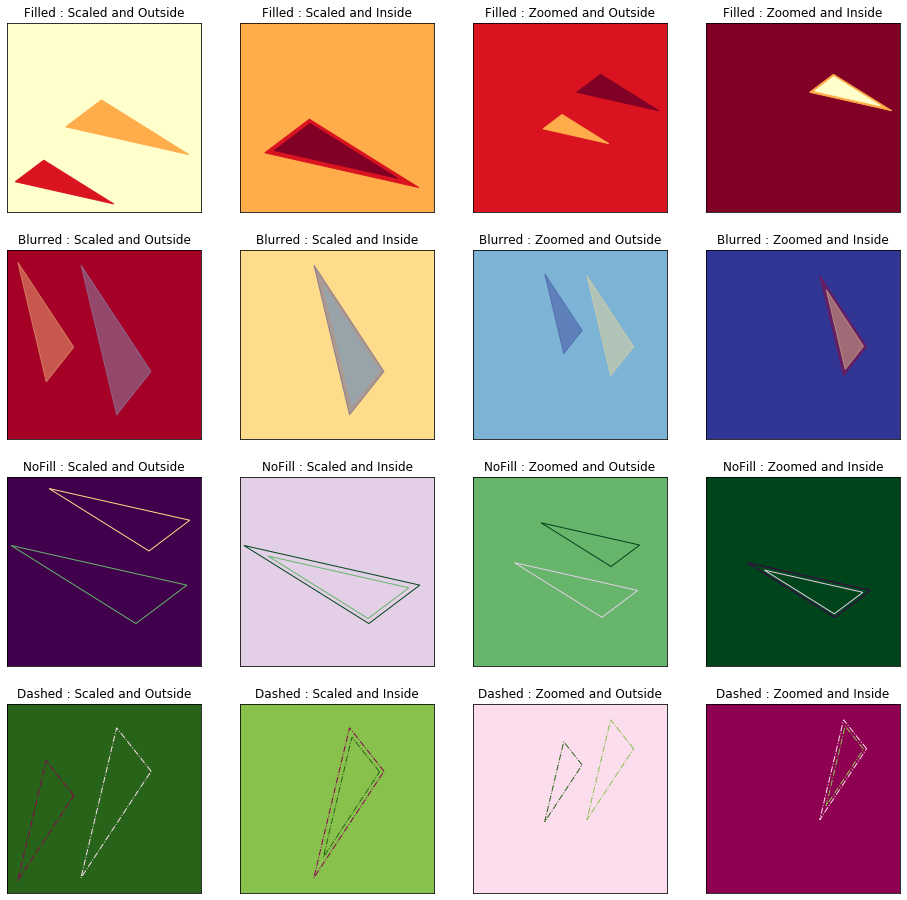

# 2. Triangles with areas different by a factor of dozen

In this step the areas of the triangle are different by a dozen.

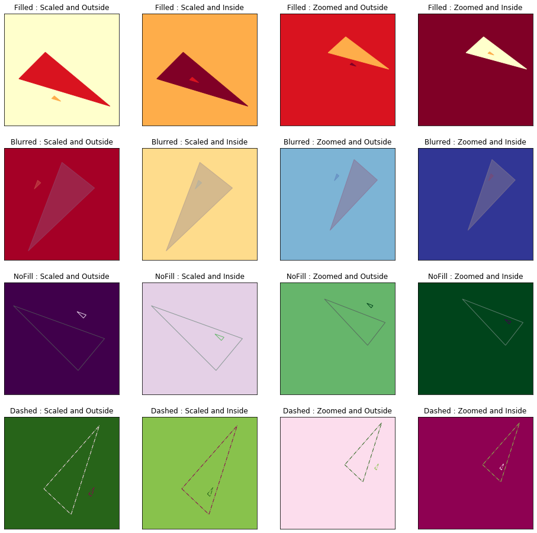

# 3. Triangles with areas different by a factor of hundred

In this step the areas of the triangle have a huge difference.

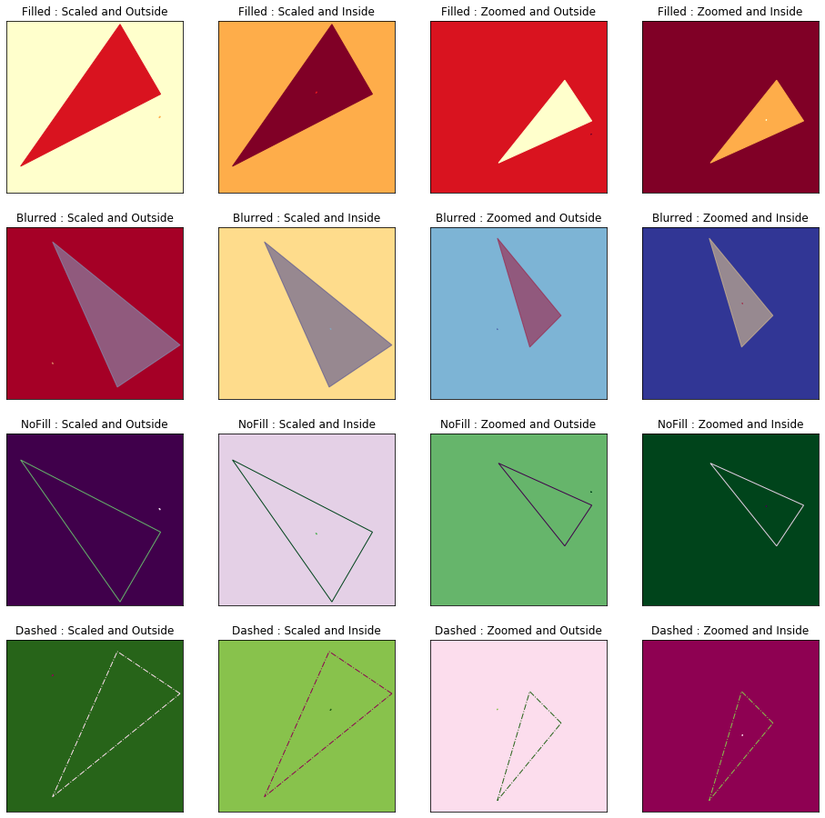

# 4. Circles with identical area

In this step the areas of the circle are nearly identical.

[figure not shown]